# Kvinnor och män i Dalarna

## 3.3 Yrken och branscher

Många arbetsuppgifter och yrken har historiskt varit könsuppdelade. Med könsuppdelningen har även värderingar om vad som räknats som formellt respektive informellt arbete synliggjorts, och hur dessa arbeten värderats i pengar. Politiska beslut har på flera sätt påverkat detta. Innan exempelvis reformerna som etablerade barn- och äldreomsorg på den reguljära arbetsmarknaden utförde kvinnor detta omsorgsarbete obetalt eller på annat sätt utanför ordinarie arbetsmarknad. När dessa arbetsuppgifter övergick till formellt arbete medförde det många positiva effekter för både kvinnor och män, men det blev på många sätt naturligt att framförallt kvinnor befolkade dessa tjänster. Dessvärre verkar det ha bidragit till en bestående könssegregering på arbetsmarknaden, som förefaller svår att förändra.

Sedan många år har kvinnor och män haft likvärdig tillgång till utbildning och möjlighet att fritt välja yrke. Trots detta består många av könsskillnaderna i arbetslivet (se figuren nedan) och de yngre generationerna tycks inte göra mindre könsstereotypa val, som redovisats i tidigare avsnitt. Många branscher i länet har idag en tydlig övervikt av det ena eller det andra könet, exempelvis byggbranschen som omfattar yrken inom bland annat el och VVS, och där kvinnor bara utgör ungefär 10 procent av de förvärvsarbetande. Även om det har skett en ökning av andelen kvinnor inom byggbranschen är denna ökning ännu liten i sammanhanget. Inom vård och omsorg är bilden densamma men med motsatt könsfördelning. Här utgör kvinnor cirka 77 procent av de förvärvsarbetande.

Att åstadkomma en förändring i närtid av balansen mellan män och kvinnor inom de könssegregerade branscherna förefaller inte vara inom räckhåll då ungdomars studieval som visats ovan är så pass könsstereotypa.

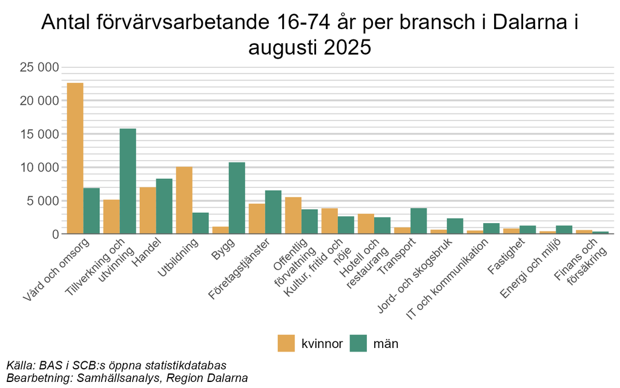

Skillnader mellan kvinnor och män föreligger således fortfarande på yrkesnivå. Den största yrkesgruppen för män i Dalarna är kategorin som inkluderar snickare, murare och anläggningsarbetare, följd av ingenjörer och tekniker. Bland kvinnor är det istället vård- och utbildningsyrken som är vanligast. Här finns exempelvis undersköterskor och grundskollärare, fritidspedagoger och förskollärare. Diagrammen nedan visar de yrken i länet som flest kvinnor respektive män arbetar inom.

Ett yrke av tio återkommer bland både kvinnor och män; butikspersonal, men detta till trots så är yrket tydligt kvinnodominerat, med ungefär 4 300 kvinnor och 2 600 män sysselsatta som butikspersonal.

Diagrammen visar också att de 10 största yrkena bland kvinnor omfattar ungefär 34 500 anställda medan de 10 största yrkena bland män omfattar ca 23 800 anställda, det vill säga, vissa kvinnodominerade yrken är också dominerande till mängd på arbetsmarknaden, vilket kan bidra till svårigheten med att bryta den könsuppdelade arbetsmarknaden.

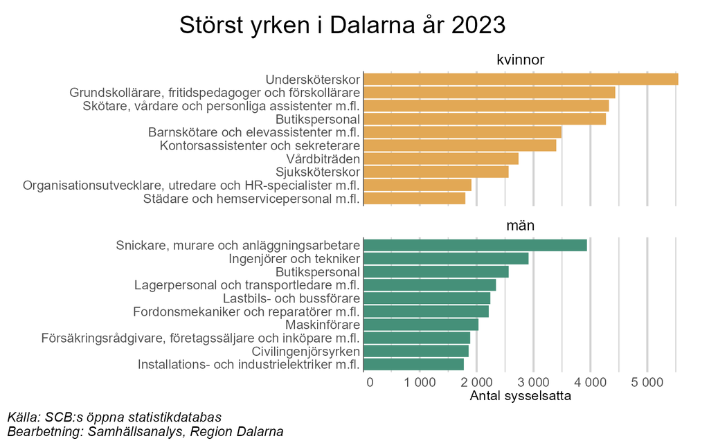

# 4 Obetalt hem- och omsorgsarbete

En jämn ansvarsfördelning för obetalt hem- och omsorgsarbete är det fjärde jämställdhetspolitiska delmålet. Jämställdhetsmyndigheten har sammanfattat nuläget för delmålet nationellt. De skriver på sin [hemsida](https://jamstalldhetsmyndigheten.se/jamstalldhet-i-sverige/delmal-4-jamn-fordelning-av-det-obetalda-hem-och-omsorgsarbetet/):

> Kvinnor tar fortfarande i hög grad ansvar för det obetalda hem- och omsorgsarbetet. De tar ut mer av föräldraförsäkringen och lägger mer tid på att ta hand om barn. Kvinnor och män ger omsorg, men på olika sätt. Kvinnors omsorgsarbete tycks dock påverka dem mer negativt än män. I hemmet är det främst kvinnor som städar, lagar mat och tvättar medan män klipper gräset, tar hand om bilen och sköter ekonomin.

Ett större ansvar för det obetalda arbetet minskar ofta utrymmet för inkomstbringande arbete och påverkar på så sätt individernas livsinkomster. Det kan också skapa ett beroende till en partner med en högre inkomst.

Det obetalda omsorgsarbetet kan mätas genom hur män och kvinnor tar ut föräldrapenning, tillfällig föräldrapenning (vab), samt närståendepenning.

## 4.1 Föräldrapenning

Antalet mottagare av föräldrapenning ökade från ungefär 13 000 i slutet av 1990-talet till över 22 000 år 2018. Givet att den absoluta majoriteten av dessa barn har två vårdnadshavare är det värt att notera att det varje år är cirka 10 procent av fäderna som inte tar ut några föräldrapenningdagar alls.

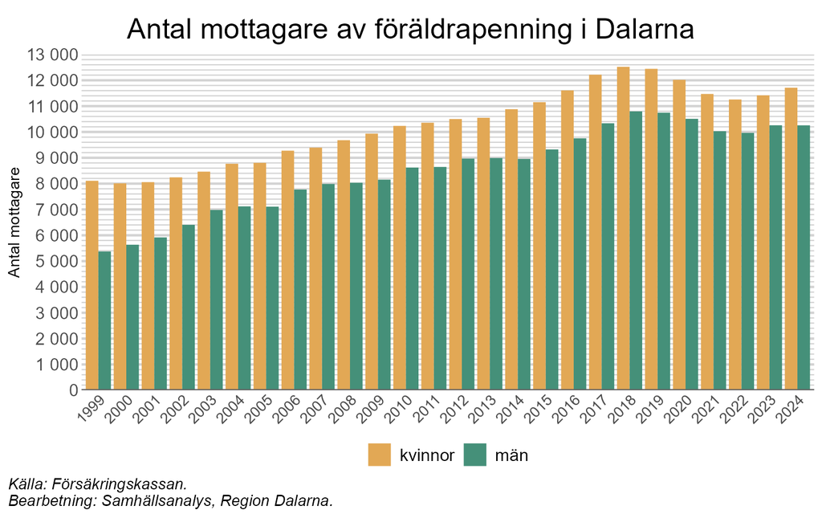

Fördelningen av dagar mellan vårdnadshavarna har jämnats ut något sedan slutet av 1990-talet då runt 85-90 procent av föräldrapenningdagarna togs ut av mammorna. Sedan dess har först en (1995), sedan två (2002) och även tre månader (2016) reserverats åt respektive vårdnadshavare (också kallade “pappamånader”). Detta har bidragit till ett jämnare uttag men utvecklingen får ändå sägas gå relativt trögt, då kvinnors andel endast har minskat till runt 69 procent 2024. Svenska vårdnadshavare är således långt ifrån att ge sina barn en jämställd tillgång till sina föräldrar. Skillnaden i uttag påverkar också den disponibla inkomsten, som beskrivits under rubriken Ekonomisk jämställdhet. Skillnaden är som störst mellan sammanboende kvinnor och män när det yngsta barnet är 0–3 år [(Regeringen, 2022)](https://www.regeringen.se/contentassets/46945970585240a4a5bfd9a0f75ecf3d/ekonomisk-jamstalldhet.pdf).

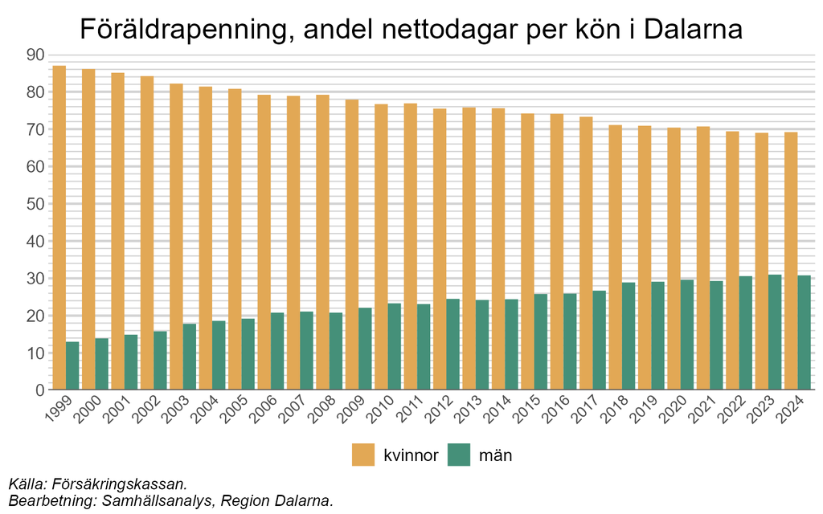

Hur vårdnadshavare fördelar föräldrapenningen mellan sig är relativt olika i Dalarnas kommuner. I Leksand är uttaget mest jämställt relativt sett, där ungefär 33 procent av föräldrapenningdagarna togs ut av männen. Minst jämställd är fördelningen i Vansbro, där motsvarande uttag är cirka 28 procent.

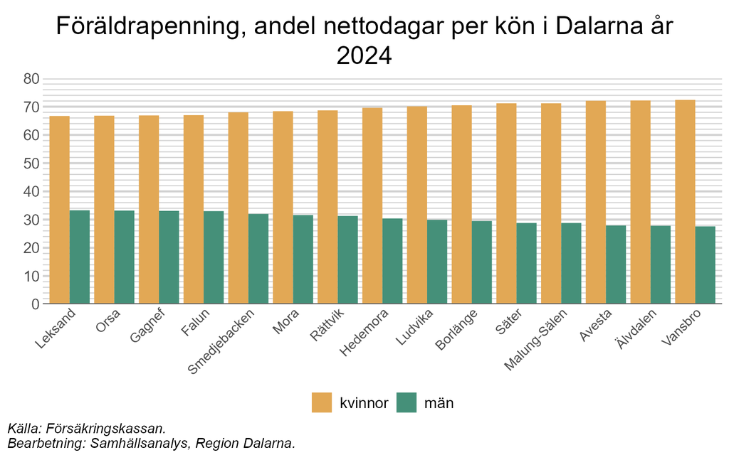

Antalet uttagna nettodagar av föräldrapenning är inte jämnt fördelade över året. Mest benägna är såväl kvinnor som män att ta ut dagar i juli och augusti, sannolikt för att ha möjlighet att vara hemma med barnen under deras skollov på sommaren. Även januari är en populär månad, troligtvis fokuserat i början av månaden när barnen är lediga från förskola och skola.

Ett påstående som ibland förs fram är att män är mer benägna att ta ut dagar under exempelvis älgjakten (september och oktober primärt) eller under större idrottsevenemang, men någon sådan tendens syns inte i statistiken som ses i diagrammet nedan. Män tar i första hand ut sina dagar under januari, juli och augusti, medan det är relativt jämnt fördelat mellan övriga månader. Visserligen sticker september ut som en månad med relativt många uttagna dagar, men det gäller för såväl kvinnor som män och bör således inte vara kopplat till eventuell älgjakt under månaden.

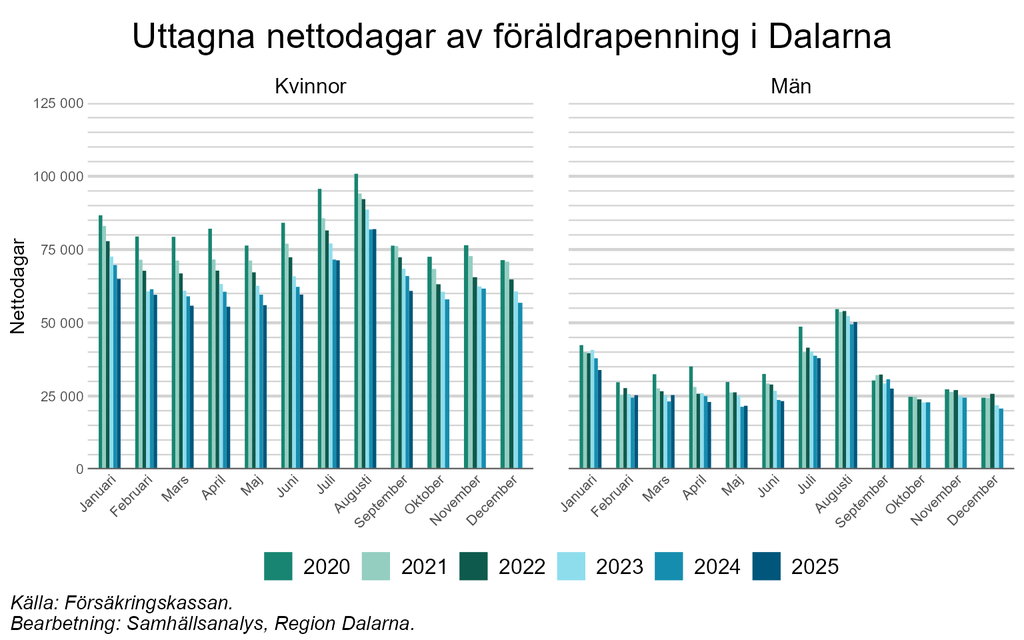

## 4.2 Tillfällig föräldrapenning

Tillfällig föräldrapenning ges för vård av sjukt barn och är det som i folkmun kallas vab. Sett över tidsperioden minskade antalet uttagna nettodagar något mellan 2006 och 2009, för att därefter öka stadigt fram till 2022. På senare år har uttaget av tillfällig föräldrapenning/vab för såväl kvinnor som män minskat, men ligger fortfarande på högre nivåer än innan pandemin. Även för vård av sjukt barn tar kvinnor ut betydligt fler dagar än män, fördelningen ligger precis utanför spannet för vad som antas som statistisk jämställdhet, där kvinnor tar ut cirka 62 procent av dagarna.

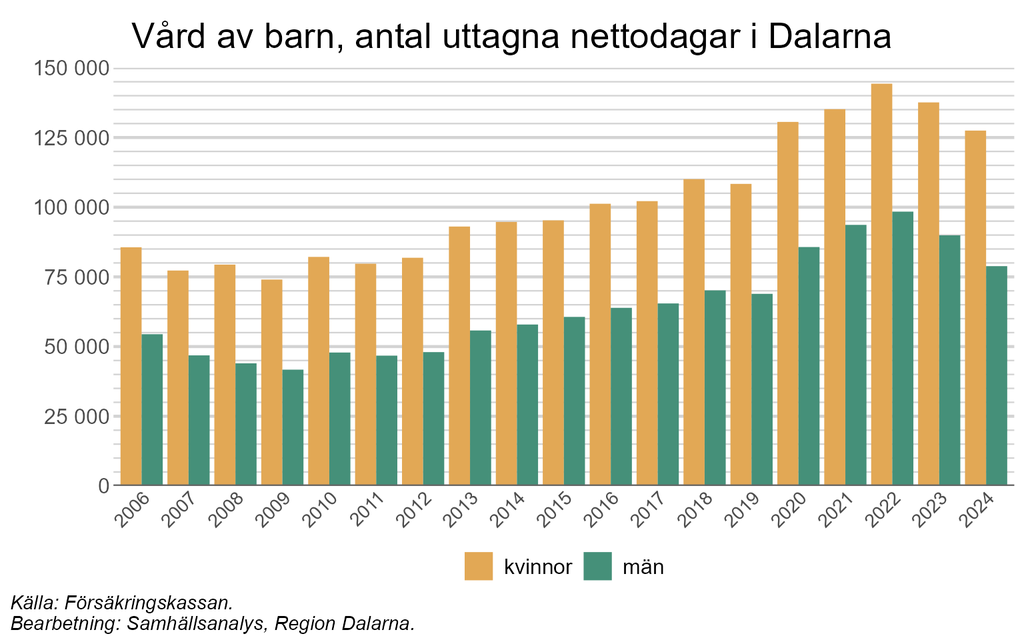

Till skillnad från trenden för föräldrapenning har fördelningen av vab-dagar hållt sig jämnare de senaste decennierna (under pandemin verkar män ha ökat sitt uttag något jämfört med kvinnor).

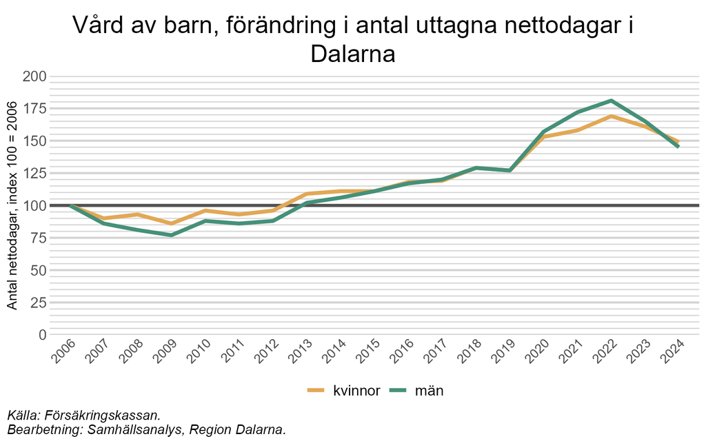

## 4.3 Närståendepenning

En del i människors behov av omsorg är när någon drabbas av ett allvarligt sjukdomstillstånd. I en sådan situation finns det stöd att få för anhörig eller närstående som avstår från förvärvsarbete för att kunna hjälpa till med vardagsomsorg om den svårt sjuke. I dessa fall ges närståendepenning.

**Mer information om statistiken**

Närståendepenning finns för att personer som har ett livshotande tillstånd ska kunna få stöd av till exempel en anhörig, vän eller granne. Men, här ingår exempelvis inte stöd till anhöriga som vårdar barn. För mer info, se [Försäkringskassan](https://www.forsakringskassan.se/privatperson/sjuk-eller-skadad/stodja-en-svart-sjuk-narstaende).

I digrammen över närståendepenning ses både antalet vårdare, dvs antalet mottagare av närståendepenning, och antalet nettodagar per grupp kvinnor respektive män sedan år 1999. Siffrorna visar att antalet vårdare och antalet nettodagar har lite mer än fördubblats bland både kvinnor och män under tidsperioden. Det är också tydligt att nivåerna fluktuerar mellan åren. Stödets utformning påverkas vissa mandatperioder av förändringar i politikens styrning, vilket kan påverka utfallet.

Sammantaget visar trenden på ett ökande behov, och det kan delvis samspela med att antalet äldre i befolkningen i Dalarna ökat över denna tidsperiod.

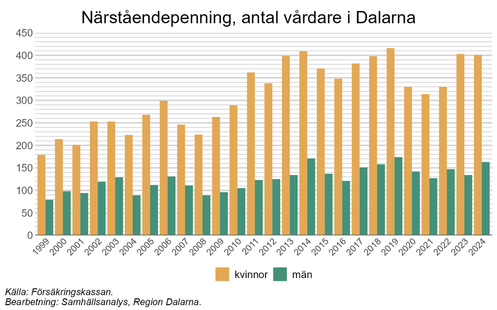

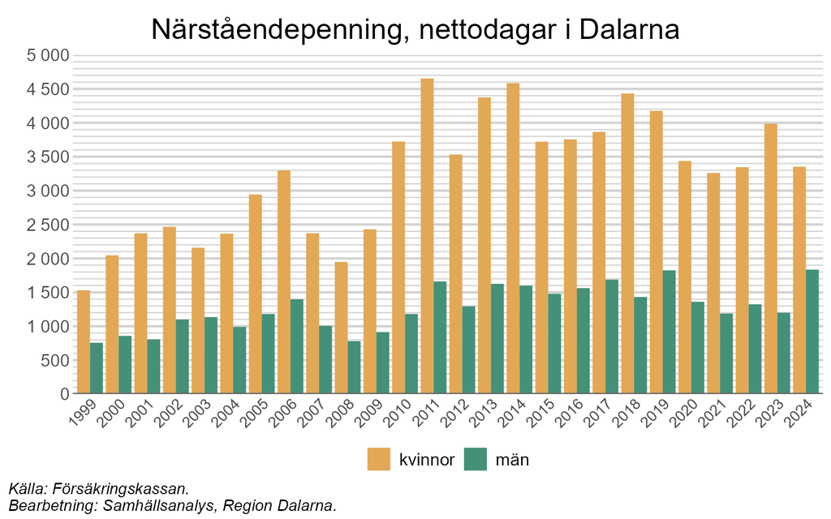

# 5 Hälsa och ohälsa

Jämställd hälsa är det femte jämställdhetspolitiska delmålet. Kvinnor och män, flickor och pojkar ska ha samma förutsättningar för en god hälsa och erbjudas vård och omsorg på lika villkor. Idag finns det stora skillnader i hälsa och ohälsa mellan kvinnor och män. Flickor och kvinnor är sjukskrivna för symptom som är kopplade till psykisk ohälsa i betydligt högre utsträckning än män, samtidigt dör fler män än kvinnor i suicid (självmord), i arbetsplatsolyckor, i hjärt- och kärlsjukdomar och av cancer. Förklaringar kan bland annat kopplas till brister i arbetsmiljön, att inte söka vård i tid och skillnader i vårdens bemötande.

Att mäta återstående medellivslängd ger en tydlig och lättbegriplig bild av befolkningens övergripande hälsoläge. Måttet fångar effekterna av både livsstilsfaktorer, arbetsmiljö, sjukdomsbörda och tillgång till vård, och visar hur dessa samspelar över tid. Eftersom det kan brytas ned på grupper som kön, utbildning och region gör det också möjligt att synliggöra ojämlikheter i hälsa. Dess stabilitet över tid gör det särskilt användbart för att följa långsiktiga förändringar och bedöma om samhällets insatser leder till förbättrad folkhälsa.

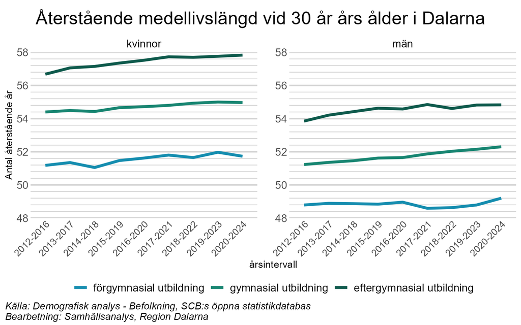

Återstående medellivslängd vid 30 års ålder i Dalarna visar tydliga skillnader mellan både utbildningsnivåer och kön. Personer med eftergymnasial utbildning har genomgående längst återstående medellivslängd, medan personer med förgymnasial utbildning har kortast. Kvinnor lever längre än män i alla utbildningsgrupper, även om gapet varierar något mellan grupperna. Utvecklingen över tid präglas av en långsam men tydlig ökning av medellivslängden för både kvinnor och män, men även ökningen är ojämnt fördelad. Under den åttaårsperiod som diagrammet visar är ökningen minst i gruppen män med förgymnasial utbildning där ökningen av medellivslängden är 0,41 år under perioden. Den grupp som har haft den största ökningen av återstående medellivslängd vid 30 års ålder är kvinnor med eftergymnasial utbildning där ökningen är 1,15 år. Skillnaden i medellivslängd mellan dessa båda grupper är 8,63 år för den senaste mätningen år 2020-2024.

En faktor som också visat sig påverka medellivslängden men som kanske inte är så uppenbar är boenderelationer, och särskilt för män. I en nationell studie från SCB framår att män med förgymnasial utbildning som är sammanboende lever i genomsnitt längre än ensamstående män med eftergymnasial utbildning. Sämst utsikter, genomsnittligt, för ett långt liv har således ensamstående män med låg utbildningsnivå [(SCB)](https://www.statistikdatabasen.scb.se/pxweb/sv/ssd/START__BE__BE0701/LivslUtbHushtyp/).

## 5.1 Ohälsotalet

Ohälsa kan följas upp på flera sätt. I detta avsnitt redovisas utfallet av de aggregerade nivåerna för ohälsotalet och sjukpenningtalet, och en fördjupning ges i stressrelaterade sjukfall och hur sjukfall fördelas över olika branscher.

Ohälsotalet[^11] mäter i vilken utsträckning personer är borta från arbetet på grund av nedsatt arbetsförmåga, mätt under ett års tid. Ohälsotalet varierar över tid och var relativt högt under början av 2000-talet. Därefter syns en klart nedåtgående trend, även om ohälsotalet har ökat något de senaste åren. Under hela tidsperioden har ohälsotalet varit högre för kvinnor än för män, även om skillnaden mellan könen har minskat något över tid.

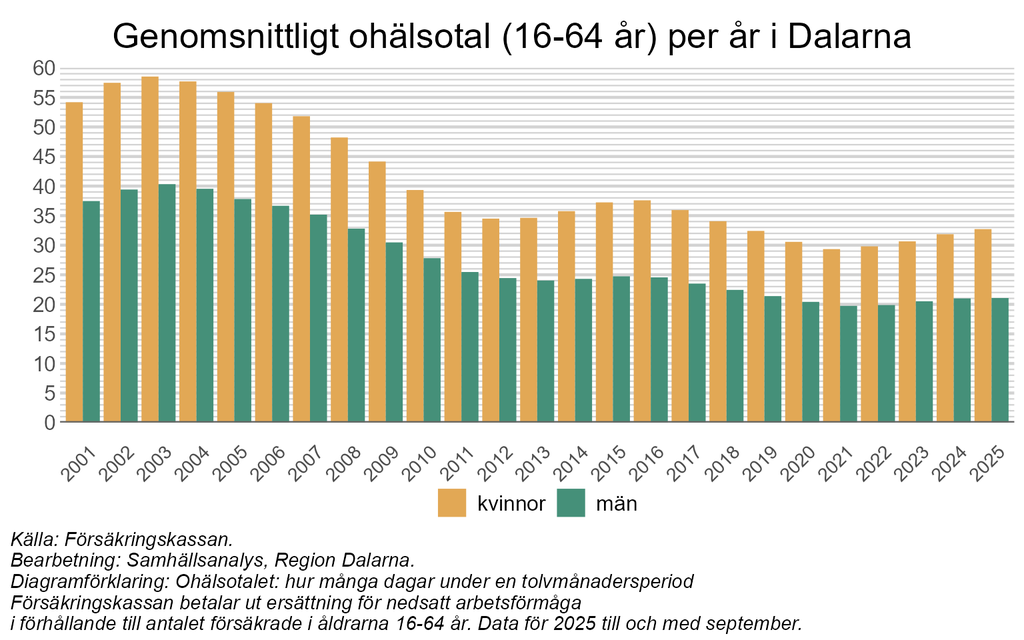

Ohälsotalet för Dalarnas befolkning visar att det finns skillnader mellan länets kommuner. För män är ohälsotalet år 2025 högst i Orsa och lägst i Falun. För kvinnor är ohälsotalet högst i Rättvik och lägst i Leksand. För att fastställa orsaken till skillnaderna mellan kommuner behövs djupare studier och analyser. Potentiella faktorer kan vara att branschstrukturen skiljer sig mellan kommunerna och att det är olika hög sjukfrånvaro i olika branscher, men även att socioekonomiska förutsättningar skiljer sig åt mellan kommunerna i Dalarna.

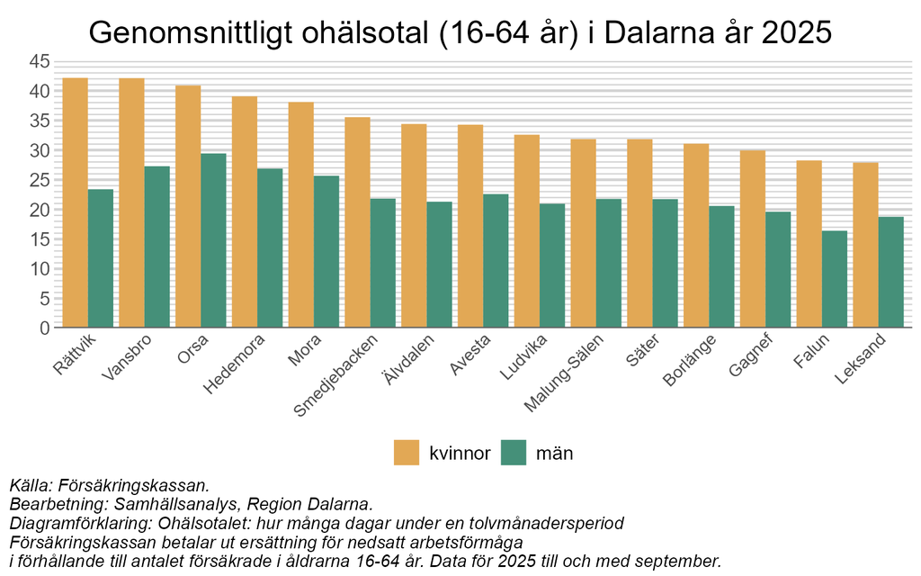

## 5.2 Sjukpenningtalet

I likhet med ohälsotalet tenderar sjukpenningtalet, som enbart innefattar sjukpenning och rehabiliteringspenning, att variera kraftigt över tiden. I början av 2000-talet var talet högt för både kvinnor och män, för att därefter minska rejält fram till 2010. Därefter har sjukpenningtalet både gått upp och ned, men på senare år kan en ökning återigen skönjas. Kvinnor är sjukskrivna i större utsträckning än män, vilket återspeglas i sjukpenningtalet. Att talet förändras över tid behöver inte nödvändigtvis bero på att människor blir mer eller mindre sjuka. Det kan snarare bero på en mer eller mindre restriktiv syn på vad som krävs för att bli sjukskriven, något som ofta är politiskt styrt. Exempelvis beror den kraftiga nedgången i sjukpenningtalet mellan 2002 och 2010 sannolikt inte främst på att arbetstagare var mindre sjuka, utan på att bedömningen av vad som berättigar en sjukskrivning var hårdare.

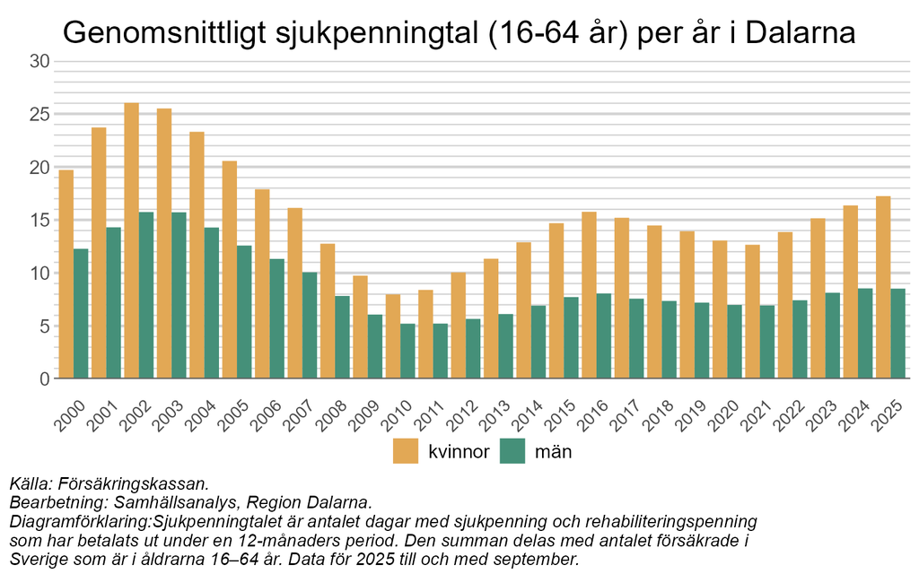

Även när det kommer till sjukpenningtalet finns det skillnader mellan Dalarnas kommuner. För både kvinnor och män är talet högst i Orsa. Sjukpenningtalet är en delmängd av ohälsotalet och därför samvarierar resultaten mellan kommunerna i stort. Talet är lägst för både kvinnor och män i Falun.

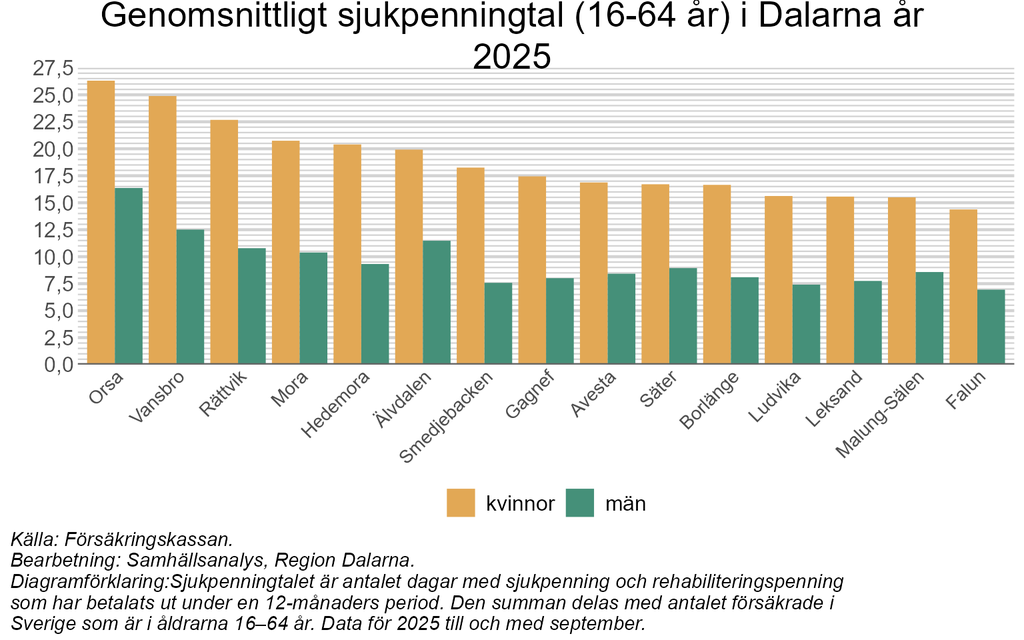

## 5.3 Stressrelaterade sjukfall

Antalet sjukfall kopplade till stressrelaterade symptom har ökat dramatiskt sedan 2010. Även för dessa sjukfall ses en trend där antalet minskade tydligt under en period fram till 2010, för att sedan öka. Kvinnor står för cirka 80 procent av dessa sjukskrivningar. Trots den stora skillnaden i antal mellan kvinnor och män, så är ökningen relativt likvärdig. Antalet pågående sjukfall kopplade till stress ökade markant för respektive grupp mellan 2010 och 2016, innan det skedde en viss minskning under åren innan och under pandemin. Därefter har det pågående sjukfallen kopplade till stress ökat tydligt för såväl kvinnor som män.

Att utröna vad det ökade antalet sjukfall beror på är svårt, men det finns ett väl belagt samband mellan psykiatriska diagnoser (såsom svår stress) och den psykosociala arbetsmiljön [(Försäkringskassan, 2016)](https://www.forsakringskassan.se/download/18.3a5418591814e228e4413b2/1661267958656/psykisk-ohalsa-korta-analyser-2016-2.pdf)[^12]. Kvinnors större ohälsa kan även kopplas till en högre grad av dubbelarbete bland kvinnor och bristande jämställdhet i nära relationer. För en fördjupad diskussion runt detta ämne, se Försäkringskassans rapport från november 2024: [“Psykisk ohälsa i dagens arbetsliv”](https://www.forsakringskassan.se/download/18.22814c2e194887717f99d/1738569517962/psykisk-ohalsa-i-dagens-arbetsliv-forsakringskassans-lagesrapport-2024-1.pdf)[^13].

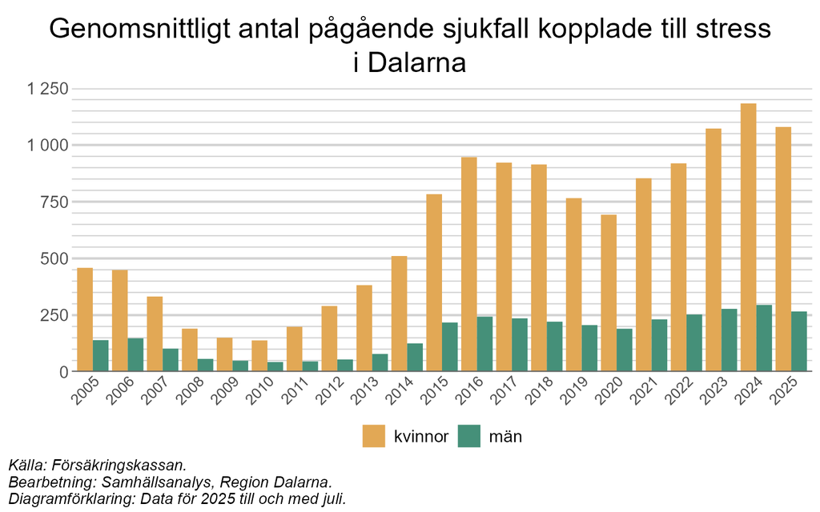

## 5.4 Sjukfall i olika branscher

Generellt är det stora skillnader i antalet startade sjukfall (per 1 000 förvärvsarbetande) mellan olika branscher. För kvinnor är antalet störst i typiskt kvinnodominerade yrken som vård och omsorg, vilket kan vara en förklaring till att kvinnor är sjukskrivna i större utsträckning än män. För män är det istället inom transport, en mansdominerad bransch, som antalet startade sjukfall är högst. Oavsett kön, är antal startade sjukfall lägst inom klassiska kontorsarbeten som ekonomi, finans och IT. Notera även att antalet startade sjukfall (per 1 000 förvärvsarbetande) är högre för kvinnor än för män i samtliga branscher i diagrammet nedan.

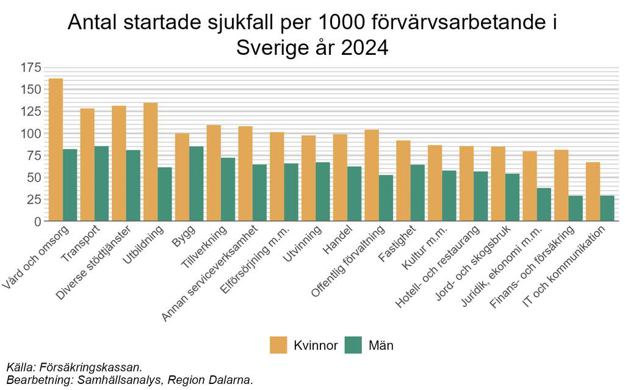

# 6 Mäns våld mot kvinnor ska upphöra

Jämställdhetsmyndigheten beskriver delmålet som att “(K)vinnor och män, flickor och pojkar ska ha samma rätt och möjlighet till kroppslig integritet. Delmålet omfattar alla yttringar av fysiskt och psykiskt, inklusive sexualiserat, våld och hot om våld samt hedersrelaterat våld och förtryck och prostitution och handel med människor för sexuella ändamål. Delmålet har även ett särskilt fokus på kopplingen mellan maskulinitet och våld.” (https://jamstalldhetsmyndigheten.se/om-jamstalldhetsmyndigheten/uppfoljning-av-jamstalldhetspolitiken/)

Delmålet följs upp genom den Nationella Trygghetsundersökningen som går att bryta ner per kön och län. Det finns statistik över anmälda brott som går att bryta ner till kategorier som överensstämmer bättre med delmålets formuleringar och vi tänker oss fördjupade analyser av den typen av data i framtiden. Det bör dock lyftas att det kan finnas en problematik med underrapportering, dvs att vissa brott inte anmäls, likväl som att Polisen ibland gör särskilda insatser för att stävja kriminalitet för vissa specifika brott vilket kan ge en ökning av antalet anmälningar utan att antalet brott i sig behöver öka.

I denna uppföljning läggs fokus på övergripande frågor kring misshandel, sexualbrott och hot samt oro och otrygghet för dessa brottskategorier och huruvida man avstått från någon aktivitet som en följd av oro. Självrapporterad utsatthet för misshandel är en bred kategori och i denna enkätfråga berörs inte förövarens kön vilket görs i delmålet. Frågan ger ändå en bild över utvecklingen av utsatthet för misshandel per kön över tid.

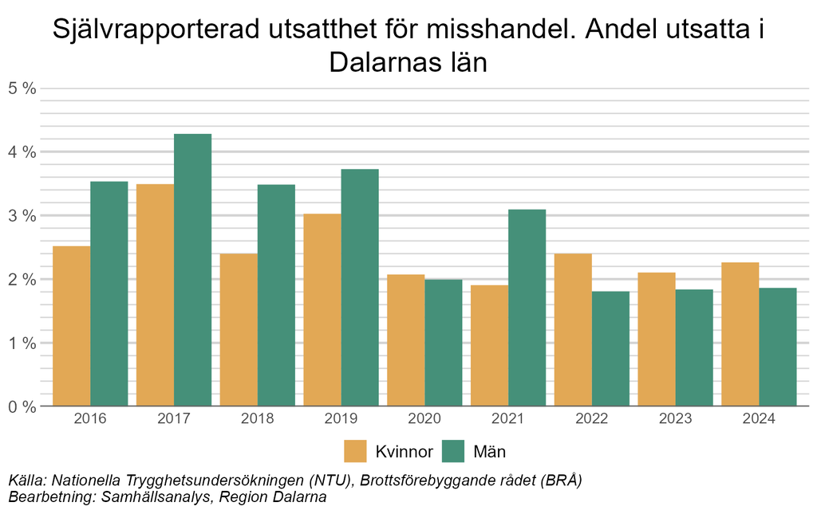

Skillnaden mellan kvinnor och män är små och varierar mellan åren. Även om det skett både upp- och nedgångar mellan åren visar den längre trenden en minskning av utsatthet för misshandel för båda könen, om än ännu tydligare bland män.

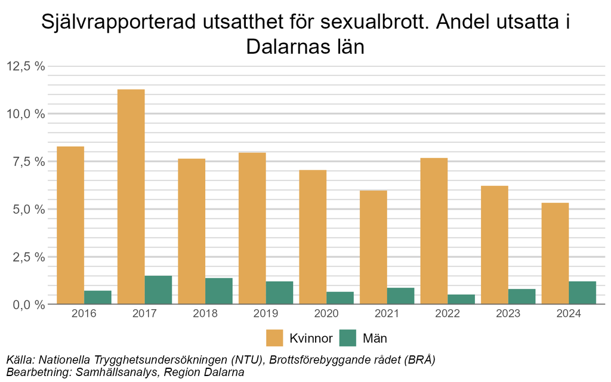

Skillnaden mellan kvinnor och män vad gäller utsatthet för sexualbrott är stor, och betydligt vanligare bland kvinnor än män. Även här sker upp- och nedgångar mellan enskilda år och även här är den längre trenden glädjande nog minskande. Åtminstone bland kvinnor.

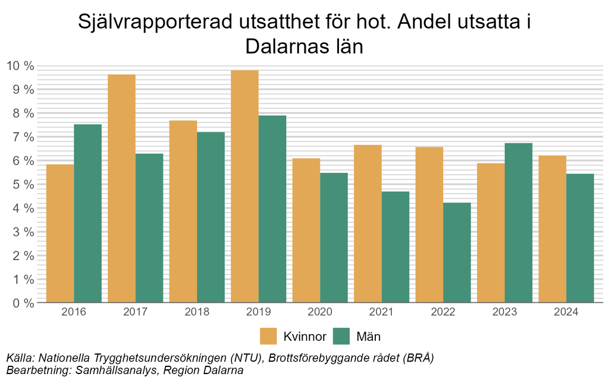

Utsatthet för hot är något större bland kvinnor än män med viss variation mellan åren, där utsattheten är större bland män vissa enstaka år. Utsattheten var särskilt stor bland kvinnor år 2017 och år 2019 men har annars legat på ungefär samma nivå alla år.

Utsatthet för brott är en kränkning i sig för den som blir utsatt, men utöver det finns individer som kanske inte har utsatts för brott men ändå känner en oro för att det ska ske. Vilket i sig kan begränsa en individs handlingsutrymme. Därför är det intressant att se huruvida oro för brott utvecklas i takt med att utsatten för samma brott förändas. Leder färre brott till en mindre oro och vice versa.

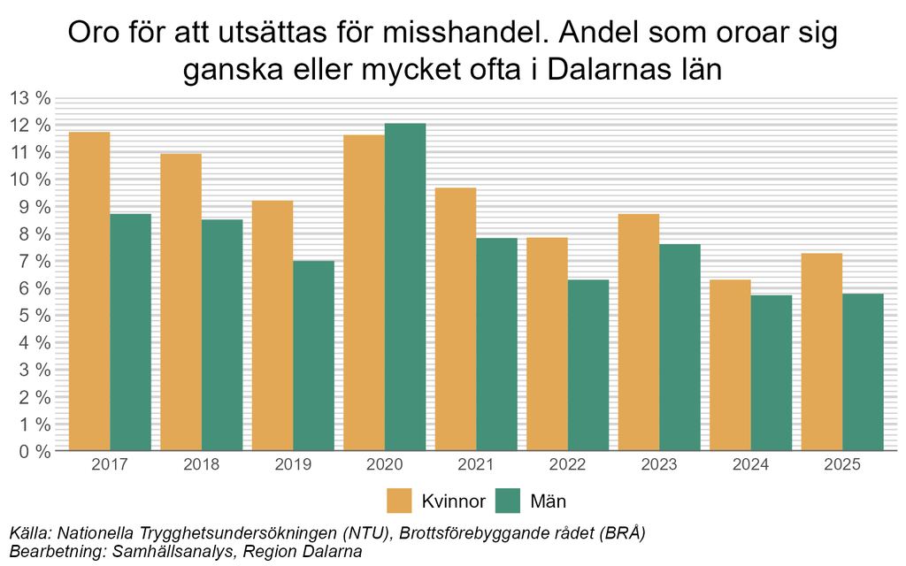

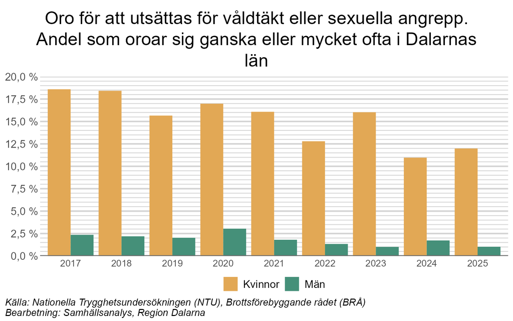

När det gäller oro för att utsättas för våldtäkt eller sexuella övergrepp är könsskillnaden stor där en väsentligt högre andel kvinnor än män känner oro. De flesta år oroar sig var sjätte kvinna i befolkningen ganska eller mycket ofta över att utsättas för dessa brott. Glädjande nog är det även här en nedåtgående trend över tid där andelen kvinnor under senare år närmar sig 10 procent. För män har andelen varierat mellan en och tre procent och även för män ser vi en trend av en sjunkande oro.

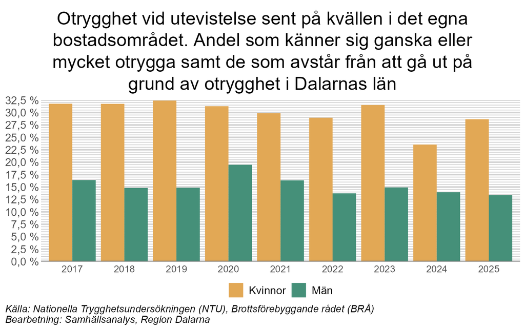

I Nationella Trygghetsundersökningen ställs också frågor om hur oro för brott påverkar otryggheten samt hur den i sin tur påverkar människors handlingar. Nästan var tredje kvinna känner sig ganska eller mycket otrygga i det egna bostadsområdet sent på kvällen, men det är en svagt sjunkande trend. Bland männen är det runt 15 procent de flesta år och även här är trenden svagt sjunkande.

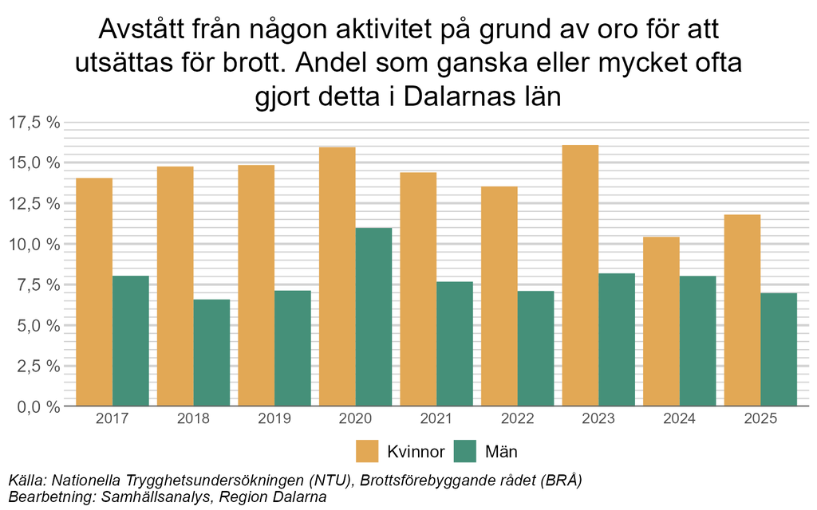

Strax under femton procent av kvinnorna har ganska eller mycket ofta avstått från någon aktivitet på grund av oro för att utsättas för brott. De senaste åren har andelen sjunkit till 10-12 procent. Bland män har det under flera år varit ungefär hälften så många, men skillnaden mellan kvinnor och män har varit mindre de senaste två åren.

Trots att utsattheten för flera brottstyper minskar över tid kvarstår stora skillnader mellan kvinnor och män – särskilt när det gäller sexualbrott och upplevd trygghet. Kvinnor utsätts i betydligt högre grad för sexualiserat våld och upplever också en större oro, vilket i sin tur påverkar deras rörelsefrihet och vardagliga val. Samtidigt visar trenderna att både utsatthet och oro sakta minskar, även i grupper där nivåerna länge varit höga. Skillnaderna mellan könen är dock tydliga och återkommande, vilket understryker behovet av fortsatt arbete med normer, trygghet och förebyggande insatser.

# Referenser

[^1]: Statistiska Centralbyrån, På tal om kvinnor och män.
[^2]: Region Dalarna, Kvinnor och män i Dalarna ur ett jämställdhetsperspektiv.
[^3]: Statistiska Centralbyrån, En fråga om tid - en studie av tidsanvändningen bland kvinnor och män 2021.
[^4]: Regeringen, Budgetproposition 2025/26:1 bilaga 3, Ekonomisk jämställdhet
[^5]: Jämställdhetsmyndigheten Regionalpolitik, könsmönster och jämställdhetsambitioner (2022:16 bilaga 1). Bilaga till rapporten “Bättre styrning för bättre resultat”.
[^6]: Regeringen (2022) Prop. 2022/23:1 Bilaga 3 Ekonomisk jämställdhet 2022
[^7]: Jämställdhetsmyndigheten (2025) En tid av förväntan, väntan och osäkerhet
[^8]: Expertgruppen för studier i offentlig ekonomi (2021)
[^9]: Jämställdhetsmyndigheten (2022)
[^10]: Etablering för fler – jämställda möjligheter till integration (SOU 2023:24)
[^11]: Ohälsotalet: hur många dagar under en tolvmånadersperiod Försäkringskassan betalar ut ersättning för nedsatt arbetsförmåga i förhållande till antalet försäkrade i åldersgruppen 16-64 år
[^12]: Försäkringskassan, Korta analyser 2016:2, “Sjukskrivning för reaktioner på svår stress ökar mest.”
[^13]: Försäkringskassans lägesrapport (2024) - “Psykisk ohälsa i dagens arbetsliv”